# P2_Entrega Final - Estadística II

### Conclusión estadística

$$p-valor > \alpha = 0.04$$

**Entonces no se rechaza la hipótesis nula**

No hay evidencia estadísticamente significativa para afirmar que las varianzas del impacto percibido de redes sociales son diferentes entre estudiantes de universidades públicas y privadas.

Ahora pasamos a evaluar el **t.test** para corroborar la hipótesis de igualdad de medias:

```r
t.test(
  DF_publico$impacto_redes_salud_mental,
  DF_privado$impacto_redes_salud_mental,
  mu = 0,
  var.equal = TRUE,
  alternative = "two.sided",
  conf.level = 0.96
)
```

```
    Two Sample t-test

data:  DF_publico$impacto_redes_salud_mental and DF_privado$impacto_redes_salud_mental
t = -0.92375, df = 364, p-value = 0.3562
alternative hypothesis: true difference in means is not equal to 0
96 percent confidence interval:
 -0.4081715  0.1555327
sample estimates:
mean of x mean of y
 3.090909  3.217228
```

**Resultados:**

- **Estadístico de prueba:** -0.92375
- **p-valor:** 0.3562
- **Intervalo de confianza:** (-0.408, 0.156)
- **Media pública:** 3.09094
- **Media privada:** 3.2172

**Gráfico:**

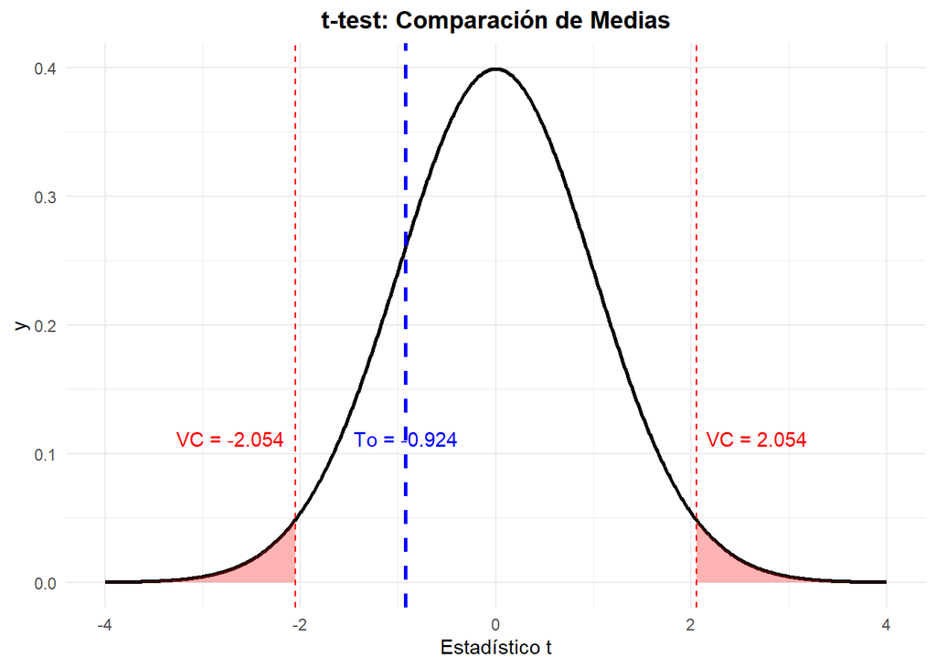

```r
# Parámetros del t-test
To <- -0.92375
VC <- 2.054   # VC positivo, para graficar uso ±VC
alfa <- 0.04

# Rango para la densidad normal / t
x_vals <- seq(-4, 4, length.out = 1000)
df_norm <- data.frame(x = x_vals, y = dnorm(x_vals))

ggplot(df_norm, aes(x, y)) +
  geom_line(size = 1) +

  # Regiones de rechazo
  geom_area(data = subset(df_norm, x <= -VC), fill="red", alpha=0.3) +
  geom_area(data = subset(df_norm, x >=  VC), fill="red", alpha=0.3) +

  # Líneas de VC
  geom_vline(xintercept = -VC, linetype="dashed", color="red") +
  geom_vline(xintercept =  VC, linetype="dashed", color="red") +

  # Estadístico
  geom_vline(xintercept = To, linetype="dashed", color="blue", size=1) +

  annotate("text", x = To, y = 0.1, label = paste("To =", round(To,3)),
           color="blue", vjust=-0.5) +

  annotate("text", x = VC, y = 0.1, label = paste("VC =", round(VC,3)),
           color="red", vjust=-0.5, hjust=-0.1) +

  annotate("text", x = -VC, y = 0.1, label = paste("VC =", round(-VC,3)),
           color="red", vjust=-0.5, hjust=1.1) +

  labs(title = "t-test: Comparación de Medias",
       x = "Estadístico t") +
  tema_grafico
```

### Conclusión estádistica

$$p-value > \alpha = 0.04$$

**No se rechaza la hipótesis nula**.

No hay evidencia estadísticamente significativa para afirmar que las medias del impacto percibido de redes sociales sobre la salud mental **difieren entre estudiantes de universidades públicas y privadas**.

Aunque privadas tiene un valor ligeramente mayor (más impacto negativo percibido), **la diferencia no es estadísticamente significativa**. Por lo tanto el impacto percibido de las redes sociales en la salud mental es similar entre estudiantes de universidades públicas y privadas.

Ambos perciben que el impacto de las redes sociales en su rendimiento es medio, lo que puede indicar que no atribuyen su bajo rendimiento al consumo de las redes sociales.

# Análisis con pruebas no parametrias

## Caso 1: Prueba de Independencia - Relación entre plataforma usada y rendimiento acadímico

En el marco de este estudio sobre hábitos digitales de estudiantes universitarios peruanos, es fundamental comprender no solo **cuánto** usan las redes sociales, sino también **cómo su elección de plataformas específicas podría estar relacionada con su rendimiento académico y bienestar**. Los estudiantes de 16 a 29 años, matriculados en universidades públicas y privadas durante el semestre 2025-1, utilizan de forma cotidiana plataformas como Instagram, TikTok, WhatsApp, Facebook o X. Estas redes presentan características distintas en cuanto a diseño, algoritmos, estímulos visuales y patrones de interacción, lo que podría generar **impactos diferenciados en la concentración y el desempeño académico**.

Dentro de este contexto, uno de los aspectos que se busca evaluar es si **la red social que un estudiante usa con mayor frecuencia** está asociada a **la percepción de afectación en su concentración y rendimiento académico**, medida en una escala ordinal de Likert del 1 al 5.

### Planteamiento de Hipótesis

La pregunta central:

**¿La red social más usada por los estudiantes está relacionada con el nivel de afectación en su concentración y rendimiento académico?**

Entonces nuestras hipótesis serían:

$$H_o: \text{La red social que el estudiante usa con mayor frecuencia no esta asociada con la percepción de rendimiento} \\$$
$$H_a: \text{La red social que el estudiante usa con mayor frecuencia esta asociada con la percepción de rendimiento}$$

De otro modo:

$$H_o: \text{Las dos variables son independientes}$$

$$H_a: \text{Las dos variables son dependientes}$$

### Resolución del caso

Primero se debe agrupar las redes sociales con muy pocos usuarios (como LinkedIn o Telegram) en una categoría “Otros”. Esto se debe a que la prueba de Chi-Cuadrado funciona cuando hay al menos 5 personas por grupo. Algunas redes solo cuentan con 1 registro, como Linkedin. Si previamente no se agrupan en otra categoría, la fórmula matemática se rompe y el resultado no sería válido.

```r
datos_red = read_csv("muestra.csv")

# Agrupación de redes sociales (Preprocesamiento necesario)
# Las redes principales se mantienen, el resto se agrupa en "Otros"
datos_red <- datos_red %>%
  mutate(red_agrupada = case_when(
    red_mas_usada %in% c("Whatsapp", "Tiktok", "Instagram") ~ red_mas_usada,
    TRUE ~ "Otros"
  )) %>%
  filter(!is.na(afecta_concentracion_rendimiento))

head(datos_red[c("red_agrupada", "afecta_concentracion_rendimiento")])
```

```
# A tibble: 6 × 2
  red_agrupada afecta_concentracion_rendimiento
  <chr>                                   <dbl>
1 Tiktok                                      5
2 Tiktok                                      3
3 Whatsapp                                    3
4 Otros                                       4
5 Whatsapp                                    3
6 Whatsapp                                    3
```

Se genera una la tabla cruzada para ver cómo se distribuyen los estudiantes según su red favorita y su nivel de afectación (1 al 5).

```r
tab <- table(datos_red$red_agrupada, datos_red$afecta_concentracion_rendimiento)
tab
```

```
             1  2  3  4  5
  Instagram  4  7 14 16 10
  Otros      6  6 12 11  8
  Tiktok     9 16 30 34 11
  Whatsapp   9 28 59 46 30
```

De la tabla se obtiene lo siguiente:

- m=4 filas (Instagram, Tiktok, WhatsApp, Otros)
- n= 5 columnas (Nivel de afectación: 1, 2, 3, 4, 5)

Por lo que, los grados de libertad serían:

**GL = (4-1)*(5-1)=12**

Ahora, se calcularán los valores esperados. Verificamos cuántos estudiantes “debería” haber en cada celda si las variables no tuvieran relación.

```r
chisq.test(tab)$expected  # Ver valores esperados en tabla cruzada
```

```
                    1         2        3        4         5
  Instagram  3.901639  7.942623 16.02459 14.90984  8.221311
  Otros      3.289617  6.696721 13.51093 12.57104  6.931694
  Tiktok     7.650273 15.573770 31.42077 29.23497 16.120219
  Whatsapp  13.158470 26.786885 54.04372 50.28415 27.726776
```

Ahora, se obtendrá el Estadístico de Prueba.

```r
chisq.test(tab)  # estadístico y p-valor
```

```
    Pearson's Chi-squared test

data:  tab
X-squared = 8.7623, df = 12, p-value = 0.7231
```

Como el **P-valor = 0.7231 > 0.04:** No rechazo $H_o$. (Las variables son independientes; usar TikTok o WhatsApp da lo mismo para la concentración).

Además, **X-squared = 8.7623** es el estadístico de prueba.

Ahora, se calcula el valor crítico que limita a la región sombreada (cola derecha) para un nivel de confianza del 96%.

$$VC=\chi^2(1-\alpha,(F-1)*(C-1))=\chi^2 (0.96, 12)$$

```r
qchisq(0.96, 12)
```

```
[1] 21.78511
```

### Conclusión

Se concluye que no existe evidencia suficiente para afirmar que la red social elegida influye en el nivel de afectación de la concentración. **Los datos son independientes**.

## Caso 2: Regla de decisión - Análisis de la salud corporal con las horas de ejercicio semanal

Se quiere implementar actividades extracurriculares para el bienestar físico y mental de los estudiantes. Como parte del estudio sobre bienestar estudiantil en universitarios peruanos de 16 a 29 años durante el semestre 2025-1, se analiza si el nivel de ejercicio semanal de los estudiantes es adecuado desde una perspectiva de salud. Las guías de la Organización Mundial de la Salud recomiendan al menos **3 horas de ejercicio a la semana** para jóvenes adultos.

Dado que la variable *horas_ejercicio_semanal* no presenta distribución normal y contiene valores discretos con asimetría, se decide aplicar una **prueba no paramétrica basada en la mediana poblacional** para evaluar si el nivel de actividad física de los estudiantes cumple con los estándares recomendados.

**Visualizando distribución de la variable de Horas de ejercicio semanal**

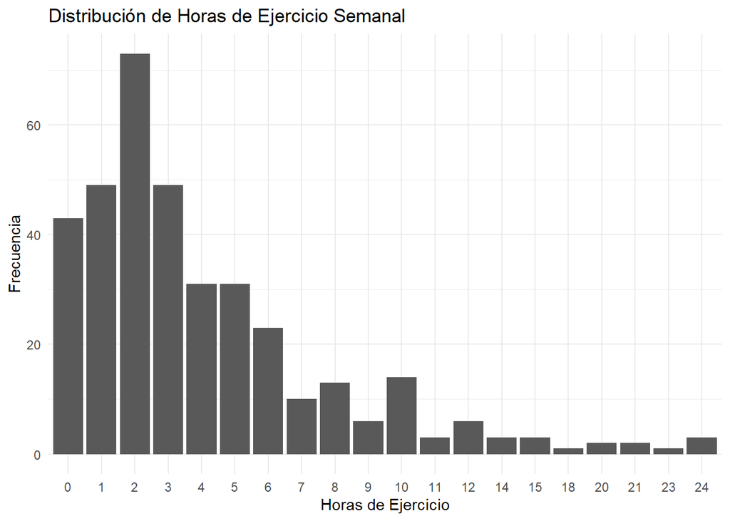

```r
DF$horas_ejercicio_semanal <- as.numeric(DF$horas_ejercicio_semanal)

ggplot(DF, aes(x = factor(horas_ejercicio_semanal))) +
  geom_bar() +
  labs(
    title = "Distribución de Horas de Ejercicio Semanal",
    x = "Horas de Ejercicio",
    y = "Frecuencia"
  ) +
  theme_minimal()
```

### Planteando Hipótesis

La pregunta central:

$$\text{¿Los estudiantes universitarios realizan en medianana al menos 3 horas semanales de ejercicio físico?}$$

Las Hipótesis serían:

$$H_o: \text{La mediana del número de horas de ejercicio semanal es almenos de 3 horas}$$
$$H_a: \text{La mediana del número de horas de ejercicio semanal es menor a 3 horas}$$

### Resolución del caso

Se deben contar cuántos estudiantes están por encima y por debajo de la mediana planteada ($M = 3$ ).

- Los que hacen **más** de 3 horas ($+$) .
- Los que hacen **menos** de 3 horas ($-$).

```r
datos_ejercicio = DF$horas_ejercicio_semanal[!is.na(DF$horas_ejercicio_semanal)]

mu=3

diferencias = datos_ejercicio - mu

n_pos = sum(diferencias > 0) #Hacen más de 3h
n_neg= sum(diferencias < 0) #Hacen menos de 3h
n_total = n_pos + n_neg

print(paste("Estudiantes con > 3 horas de ejercicio (+):", n_pos, "\n"))
```

```
[1] "Estudiantes con > 3 horas de ejercicio (+): 152 \n"
```

```r
print(paste("Estudiantes con < 3 horas de ejercicio (-):", n_neg, "\n"))
```

```
[1] "Estudiantes con < 3 horas de ejercicio (-): 165 \n"
```

```r
print(paste("Total de estudiantes (n):", n_total))
```

```
[1] "Total de estudiantes (n): 317"
```

152 estudiantes superan las 3 horas de ejercicio, mientras que 165 no alcanzan dicha cifra. Aunque hay más estudiantes en el grupo negativo, la diferencia no es significativa.

Se utilizará la Prueba de Signos debido a la naturaleza no paramétrica de la variable a evaluar. Esta prueba permite evaluar si esta mediana poblacional difiere significativamente del estándar de 3 horas.

```r
resultado_signo = SIGN.test(datos_ejercicio, md = 3, alternative = "less", conf.level = 0.96)

print(resultado_signo)
```

```
    One-sample Sign-Test

data:  datos_ejercicio
s = 152, p-value = 0.2502
alternative hypothesis: true median is less than 3
96 percent confidence interval:
 -Inf    3
sample estimates:
median of x
          3

Achieved and Interpolated Confidence Intervals:

                  Conf.Level L.E.pt U.E.pt
Lower Achieved CI     0.9578   -Inf      3
Interpolated CI       0.9600   -Inf      3
Upper Achieved CI     0.9664   -Inf      3
```

### Conclusión

Al realizar la prueba de signos con un nivel de confianza del 96% ($\alpha = 0.04$), obtuvimos un P-valor de 0.2502. Dado que $0.2502 > 0.04$, no se rechaza la Hipótesis Nula.

Se concluye que la mediana poblacional es al menos 3 horas, por lo que los, en la población de estudiantes, se está cumpliendo elestándar mínimo de la OMS.

## Caso 3: Prueba de bondad de Ajuste - Analísis del patrón de uso de redes sociales en un día

Uno de nuestros objetivos es **identificar los patrones de uso de redes sociales**, y una forma de hacerlo es evaluar si el uso se distribuye uniformemente a lo largo del día.

Si encontramos diferencias significativas, esto permite entender cuándo los estudiantes están más conectados y cómo eso puede relacionarse con el rendimiento académico o la calidad del sueño.

### Resolución del caso

Encontramos los datos para poder crear nuestra tabla con las Frecuencias observadas, la probabilidad respecto a la distribución uniforme y el valor esperado que deberían tener. Además de la prueba del Chi-cuadrado.

```r
# Creamos las tablas de frecuencia Real
observadas <- table(DF$momento_uso_redes_sociales)
observadas
```

```
 Madrugada (12am-6am) Mañana (6am-11:59 am)      Noche(6pm-12 am)
                   12                    18                   226
  Tarde (12 pm - 6pm)
                  109
```

```r
# Número de categorías
k <- length(observadas)
```

```r
# Frecuencias esperadas (modelo uniforme)
esperadas <- rep(sum(observadas) / k, k)
esperadas
```

```
[1] 91.25 91.25 91.25 91.25
```

```r
# Contribuciones al Chi-cuadrado
chi_contrib <- (observadas - esperadas)^2 / esperadas
chi_contrib
```

```
 Madrugada (12am-6am) Mañana (6am-11:59 am)      Noche(6pm-12 am)
             68.82808              58.80068             198.98699
  Tarde (12 pm - 6pm)
              3.45274
```

```r
# Porcentajes
porcentaje <- round(observadas / sum(observadas) * 100, 2)
porcentaje
```

```
 Madrugada (12am-6am) Mañana (6am-11:59 am)      Noche(6pm-12 am)
                 3.29                  4.93                 61.92
  Tarde (12 pm - 6pm)
                29.86
```

```r
# Prueba Chi-cuadrado
chi_test <- chisq.test(x = observadas, p = rep(1/k, k))

chi_test
```

```
    Chi-squared test for given probabilities

data:  observadas
X-squared = 330.07, df = 3, p-value < 2.2e-16
```

```r
# Tabla final
tabla_resultado <- data.frame(
  Momento_del_dia = c(
    "Madrugada (12 am – 6 am)",
    "Mañana (6 am – 11:59 am)",
    "Tarde (12 pm – 6 pm)",
    "Noche (6 pm – 12 am)"
  ),
  Frecuencia_observada = as.numeric(observadas),
  Frecuencia_esperada = round(esperadas, 2),
  Contribucion_Chi2 = round(chi_contrib, 2),
  Porcentaje = porcentaje
)

tabla_resultado
```

```
           Momento_del_dia Frecuencia_observada Frecuencia_esperada
1 Madrugada (12 am – 6 am)                   12               91.25
2 Mañana (6 am – 11:59 am)                   18               91.25
3     Tarde (12 pm – 6 pm)                  226               91.25
4     Noche (6 pm – 12 am)                  109               91.25
  Contribucion_Chi2.Var1 Contribucion_Chi2.Freq       Porcentaje.Var1
1   Madrugada (12am-6am)                  68.83  Madrugada (12am-6am)
2  Mañana (6am-11:59 am)                  58.80 Mañana (6am-11:59 am)
3       Noche(6pm-12 am)                 198.99      Noche(6pm-12 am)
4    Tarde (12 pm - 6pm)                   3.45   Tarde (12 pm - 6pm)
  Porcentaje.Freq
1            3.29
2            4.93
3           61.92
4           29.86
```

**Tabla final armada:**

| Momento del día | Frecuencia observada | Frecuencia esperada | Contribución al Chi-cuadrado | Porcentaje del total |
| --- | --- | --- | --- | --- |
| Madrugada (12 am – 6 am) | 12 | 91.25 | 68.83 | 3.29% |
| Mañana (6 am – 11:59 am) | 18 | 91.25 | 58.80 | 4.93% |
| Tarde (12 pm – 6 pm) | 109 | 91.25 | 3.45 | 29.86% |
| Noche (6 pm – 12 am) | 226 | 91.25 | 198.99 | 61.92% |
| **Total** | 365 | — | **330.07** | **100%** |

### Conclusión

Dado que:

- El p-valor es mucho menor a 0.05
- El estadístico Chi-cuadrado es extremamente alto (330.07)

Se rechaza la hipótesis nula ($H_o$), el uso de redes sociales No es unirme a lo largo del día. Esto significa que hay diferencias altamente significativas entre los momentos del día, y los estudiantes prefieren claramente ciertos horarios.

**Patrón encontrado:**

- **La noche (226)** es, por amplio margen, el momento con mayor uso.
- Le sigue la **tarde (109)**.
- La **mañana (18)** y la **madrugada (12)** presentan un uso muy reducido.

Esto indica que el uso de redes sociales presenta un patrón claramente diferenciado a lo largo del día, concentrándose principalmente en las horas de la noche. Este hallazgo es relevante para comprender los hábitos digitales de los estudiantes universitarios y constituye un insumo para analizar su relación con el rendimiento académico, la calidad del sueño y la salud mental. Ya que usar redes sociales de noche y madrugada suele estar asociado a:

- procrastinación
- distracción digital
- mala higiene del sueño

# Diseño del Experimento - Anova factor

## Contexto y Objetivo

En el marco del estudio sobre salud mental digital, resulta crucial analizar cómo el **uso nocturno de redes sociales** impacta en la **calidad del sueño** de los estudiantes universitarios. Múltiples investigaciones han documentado que el uso de dispositivos electrónicos antes de dormir puede alterar los patrones de sueño y afectar el descanso *(Twenge, 2019)*.

En esta sección, aplicaremos un **diseño experimental de un factor** mediante **ANOVA (Análisis de Varianza)** para determinar si existen diferencias significativas en las **horas de sueño por noche** entre estudiantes con diferentes niveles de uso nocturno de redes sociales.

### Pregunta de investigación

**¿Existen diferencias significativas en las horas de sueño promedio entre estudiantes con bajo, moderado y alto uso nocturno de redes sociales?**

### Diseño del experimento

**Factor de estudio:** - Nivel de uso nocturno de redes sociales (variable categórica con 3 niveles)

**Variable respuesta:** - Horas de sueño por noche (variable cuantitativa continua)

**Grupos experimentales:**

- **Grupo 1 (Bajo uso):** Estudiantes que usan redes sociales 0-2 días por semana antes de dormir
- **Grupo 2 (Uso moderado):** Estudiantes que usan redes sociales 3-4 días por semana antes de dormir
- **Grupo 3 (Alto uso):** Estudiantes que usan redes sociales 5-7 días por semana antes de dormir

### Hipótesis

**Hipótesis nula (H₀):** Las medias de horas de sueño son iguales en los tres grupos de uso nocturno de redes sociales.

$$H_0: \mu_1 = \mu_2 = \mu_3$$

**Hipótesis alternativa (H₁):** Al menos una de las medias de horas de sueño difiere entre los grupos.

$$H_1: \text{Al menos un } \mu_i \neq \mu_j \text{ para } i \neq j$$

**Nivel de significancia:** α = 0.04 (correspondiente a 96% de confianza)

## Preparación de Datos

```r
# Crear variable categórica para niveles de uso nocturno
datos_anova <- DF %>%
  filter(!is.na(dias_redes_antes_de_dormir), !is.na(horas_sueño_xnoche)) %>%
  mutate(
    nivel_uso_nocturno = case_when(
      dias_redes_antes_de_dormir >= 0 & dias_redes_antes_de_dormir <= 2 ~ "Bajo (0-2 días)",
      dias_redes_antes_de_dormir >= 3 & dias_redes_antes_de_dormir <= 4 ~ "Moderado (3-4 días)",
      dias_redes_antes_de_dormir >= 5 & dias_redes_antes_de_dormir <= 7 ~ "Alto (5-7 días)",
      TRUE ~ NA_character_
    )
  ) %>%
  filter(!is.na(nivel_uso_nocturno)) %>%
  mutate(nivel_uso_nocturno = factor(nivel_uso_nocturno,
                                      levels = c("Bajo (0-2 días)", "Moderado (3-4 días)", "Alto (5-7 días)")))

# Verificar tamaños de grupo
table(datos_anova$nivel_uso_nocturno)
```

```
    Bajo (0-2 días) Moderado (3-4 días)     Alto (5-7 días)
                 35                  44                 287
```

## Análisis Descriptivo por Grupos

```r
# Estadísticas descriptivas por grupo
estadisticas_grupos <- datos_anova %>%
  group_by(nivel_uso_nocturno) %>%
  summarise(
    n = n(),
    Media = mean(horas_sueño_xnoche, na.rm = TRUE),
    Mediana = median(horas_sueño_xnoche, na.rm = TRUE),
    Desv_Est = sd(horas_sueño_xnoche, na.rm = TRUE),
    Varianza = var(horas_sueño_xnoche, na.rm = TRUE),
    Min = min(horas_sueño_xnoche, na.rm = TRUE),
    Max = max(horas_sueño_xnoche, na.rm = TRUE),
    Error_Est = sd(horas_sueño_xnoche, na.rm = TRUE) / sqrt(n())
  )

kable(estadisticas_grupos, digits = 3,
      caption = "Tabla 4: Estadísticas descriptivas de horas de sueño por nivel de uso nocturno de redes",
      col.names = c("Nivel de Uso Nocturno", "n", "Media", "Mediana", "Desv. Est.",
                    "Varianza", "Mín", "Máx", "Error Est.")) %>%
  kable_styling(bootstrap_options = c("striped", "hover", "condensed", "responsive"),
                full_width = TRUE, font_size = 12) %>%
  row_spec(0, bold = TRUE, color = "white", background = "#3498db")
```

Tabla 4: Estadísticas descriptivas de horas de sueño por nivel de uso nocturno de redes

| Nivel de Uso Nocturno | n | Media | Mediana | Desv. Est. | Varianza | Mín | Máx | Error Est. |
| --- | --- | --- | --- | --- | --- | --- | --- | --- |
| Bajo (0-2 días) | 35 | 6.314 | 6 | 1.623 | 2.634 | 0 | 8 | 0.274 |
| Moderado (3-4 días) | 44 | 6.409 | 6 | 1.127 | 1.271 | 3 | 8 | 0.170 |
| Alto (5-7 días) | 287 | 6.258 | 6 | 1.163 | 1.353 | 1 | 8 | 0.069 |

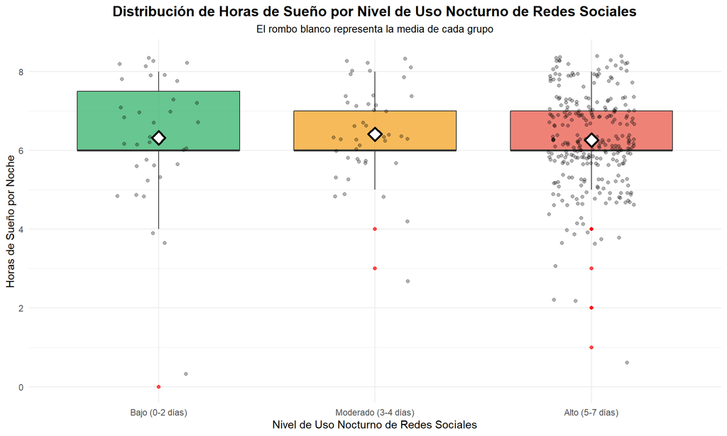

```r
# Boxplot comparativo
ggplot(datos_anova, aes(x = nivel_uso_nocturno, y = horas_sueño_xnoche, fill = nivel_uso_nocturno)) +
  geom_boxplot(alpha = 0.7, outlier.color = "red") +
  geom_jitter(width = 0.2, alpha = 0.3, size = 1.5) +
  stat_summary(fun = mean, geom = "point", shape = 23, size = 4,
               fill = "white", color = "black", stroke = 1.5) +
  labs(title = "Distribución de Horas de Sueño por Nivel de Uso Nocturno de Redes Sociales",
       subtitle = "El rombo blanco representa la media de cada grupo",
       x = "Nivel de Uso Nocturno de Redes Sociales",
       y = "Horas de Sueño por Noche",
       fill = "Grupo") +
  scale_fill_manual(values = c("#27ae60", "#f39c12", "#e74c3c")) +
  theme_minimal() +
  theme(legend.position = "none",
        plot.title = element_text(hjust = 0.5, face = "bold", size = 14),
        plot.subtitle = element_text(hjust = 0.5, size = 10),
        axis.text.x = element_text(angle = 0, hjust = 0.5))
```

## Verificación de Supuestos del ANOVA

Antes de proceder con el ANOVA, debemos verificar que se cumplan los supuestos:

### 1. Normalidad de los residuos en cada grupo

```r
# Prueba de Shapiro-Wilk por grupo
normalidad_tests <- datos_anova %>%
  group_by(nivel_uso_nocturno) %>%
  summarise(
    n = n(),
    Shapiro_W = shapiro.test(horas_sueño_xnoche)$statistic,
    p_valor = shapiro.test(horas_sueño_xnoche)$p.value,
    Normal = ifelse(shapiro.test(horas_sueño_xnoche)$p.value > 0.04, "Sí", "No")
  )

kable(normalidad_tests, digits = 4,
      caption = "Tabla 5: Pruebas de normalidad (Shapiro-Wilk) por grupo",
      col.names = c("Grupo", "n", "Estadístico W", "p-valor", "¿Normal? (α=0.04)")) %>%
  kable_styling(bootstrap_options = c("striped", "hover", "condensed"),
                full_width = FALSE, font_size = 12) %>%
  row_spec(0, bold = TRUE, color = "white", background = "#3498db")
```

Tabla 5: Pruebas de normalidad (Shapiro-Wilk) por grupo

| Grupo | n | Estadístico W | p-valor | ¿Normal? (α=0.04) |
| --- | --- | --- | --- | --- |
| Bajo (0-2 días) | 35 | 0.8221 | 1e-04 | No |
| Moderado (3-4 días) | 44 | 0.8972 | 9e-04 | No |
| Alto (5-7 días) | 287 | 0.8998 | 0e+00 | No |

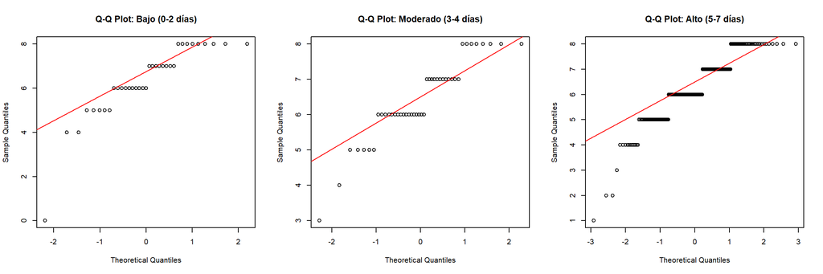

```r
# Q-Q plots por grupo
par(mfrow = c(1, 3))
for (grupo in levels(datos_anova$nivel_uso_nocturno)) {
  datos_grupo <- datos_anova %>% filter(nivel_uso_nocturno == grupo)
  qqnorm(datos_grupo$horas_sueño_xnoche, main = paste("Q-Q Plot:", grupo))
  qqline(datos_grupo$horas_sueño_xnoche, col = "red")
}
```

### 2. Homogeneidad de varianzas (Homocedasticidad)

```r
# Prueba de Levene para homogeneidad de varianzas
levene_test <- leveneTest(horas_sueño_xnoche ~ nivel_uso_nocturno, data = datos_anova)

cat("Prueba de Levene para homogeneidad de varianzas:\n")
```

```
Prueba de Levene para homogeneidad de varianzas:
```

```r
print(levene_test)
```

```
Levene's Test for Homogeneity of Variance (center = median)
       Df F value Pr(>F)
group   2  2.0417 0.1313
      363
```

```r
if (levene_test$`Pr(>F)`[1] > 0.04) {
  cat("\nConclusión: No rechazamos H₀. Las varianzas son homogéneas entre grupos (α = 0.04)\n")
  cat("✓ Se cumple el supuesto de homocedasticidad para ANOVA\n")
} else {
  cat("\nConclusión: Rechazamos H₀. Las varianzas NO son homogéneas entre grupos (α = 0.04)\n")
  cat("✗ Considerar prueba no paramétrica (Kruskal-Wallis) o Welch ANOVA\n")
}
```

```
Conclusión: No rechazamos H₀. Las varianzas son homogéneas entre grupos (α = 0.04)
✓ Se cumple el supuesto de homocedasticidad para ANOVA
```

```r
# Prueba alternativa: Bartlett (más sensible a no-normalidad)
bartlett_test <- bartlett.test(horas_sueño_xnoche ~ nivel_uso_nocturno, data = datos_anova)

cat("\nPrueba de Bartlett para homogeneidad de varianzas:\n")
```

```
Prueba de Bartlett para homogeneidad de varianzas:
```

```r
cat(sprintf("Estadístico de Bartlett = %.4f, p-valor = %.4f\n",
            bartlett_test$statistic, bartlett_test$p.value))
```

```
Estadístico de Bartlett = 8.4041, p-valor = 0.0150
```

### 3. Independencia de observaciones

La independencia se garantiza por el diseño del estudio (cada estudiante pertenece a un solo grupo y las observaciones son independientes entre sí).

## ANOVA de Un Factor

```r
# Ajustar modelo ANOVA
modelo_anova <- aov(horas_sueño_xnoche ~ nivel_uso_nocturno, data = datos_anova)

# Tabla ANOVA
anova_summary <- summary(modelo_anova)
print(anova_summary)
```

```
                    Df Sum Sq Mean Sq F value Pr(>F)
nivel_uso_nocturno   2    0.9  0.4573   0.313  0.732
Residuals          363  531.1  1.4631
```

### Construcción Manual de la Tabla ANOVA

```r
# Extraer componentes de la tabla ANOVA
anova_table <- anova_summary[[1]]

# Calcular componentes manualmente para verificación
media_global <- mean(datos_anova$horas_sueño_xnoche)
n_total <- nrow(datos_anova)
k <- length(levels(datos_anova$nivel_uso_nocturno))  # número de grupos

# Suma de cuadrados entre grupos (SCE)
SC_entre <- sum(estadisticas_grupos$n * (estadisticas_grupos$Media - media_global)^2)

# Suma de cuadrados dentro de grupos (SCD)
SC_dentro <- sum((estadisticas_grupos$n - 1) * estadisticas_grupos$Varianza)

# Suma de cuadrados total
SC_total <- SC_entre + SC_dentro

# Grados de libertad
gl_entre <- k - 1
gl_dentro <- n_total - k
gl_total <- n_total - 1

# Cuadrados medios
MC_entre <- SC_entre / gl_entre
MC_dentro <- SC_dentro / gl_dentro

# Estadístico F
F_stat <- MC_entre / MC_dentro

# p-valor
p_valor <- pf(F_stat, gl_entre, gl_dentro, lower.tail = FALSE)

# Crear tabla ANOVA formateada
tabla_anova_completa <- data.frame(
  Fuente = c("Entre grupos (Factor)", "Dentro de grupos (Error)", "Total"),
  SC = c(SC_entre, SC_dentro, SC_total),
  gl = c(gl_entre, gl_dentro, gl_total),
  MC = c(MC_entre, MC_dentro, NA),
  F = c(F_stat, NA, NA),
  p_valor = c(p_valor, NA, NA)
)

kable(tabla_anova_completa, digits = 4,
      caption = "Tabla 6: Tabla ANOVA completa - Efecto del uso nocturno de redes en horas de sueño",
      col.names = c("Fuente de Variación", "Suma de Cuadrados", "Grados de Libertad",
                    "Cuadrado Medio", "F", "p-valor")) %>%
  kable_styling(bootstrap_options = c("striped", "hover", "condensed", "responsive"),
                full_width = TRUE, font_size = 12) %>%
  row_spec(0, bold = TRUE, color = "white", background = "#3498db") %>%
  row_spec(3, bold = TRUE)
```

Tabla 6: Tabla ANOVA completa - Efecto del uso nocturno de redes en horas de sueño

| Fuente de Variación | Suma de Cuadrados | Grados de Libertad | Cuadrado Medio | F | p-valor |
| --- | --- | --- | --- | --- | --- |
| Entre grupos (Factor) | 0.9146 | 2 | 0.4573 | 0.3126 | 0.7318 |
| Dentro de grupos (Error) | 531.0991 | 363 | 1.4631 | NA | NA |
| Total | 532.0137 | 365 | NA | NA | NA |

## Comparaciones Múltiples (Post-hoc)

Si el ANOVA resulta significativo, procedemos con comparaciones post-hoc para identificar qué grupos específicos difieren entre sí.

```r
# Prueba de Tukey HSD (Honest Significant Difference) al 96% de confianza
tukey_result <- TukeyHSD(modelo_anova, conf.level = 0.96)
print(tukey_result)
```

```
  Tukey multiple comparisons of means
    96% family-wise confidence level

Fit: aov(formula = horas_sueño_xnoche ~ nivel_uso_nocturno, data = datos_anova)

$nivel_uso_nocturno
                                           diff        lwr       upr     p adj
Moderado (3-4 días)-Bajo (0-2 días)  0.09480519 -0.5739598 0.7635702 0.9361356
Alto (5-7 días)-Bajo (0-2 días)     -0.05644599 -0.5851022 0.4722102 0.9632473
Alto (5-7 días)-Moderado (3-4 días) -0.15125119 -0.6292943 0.3267919 0.7202358
```

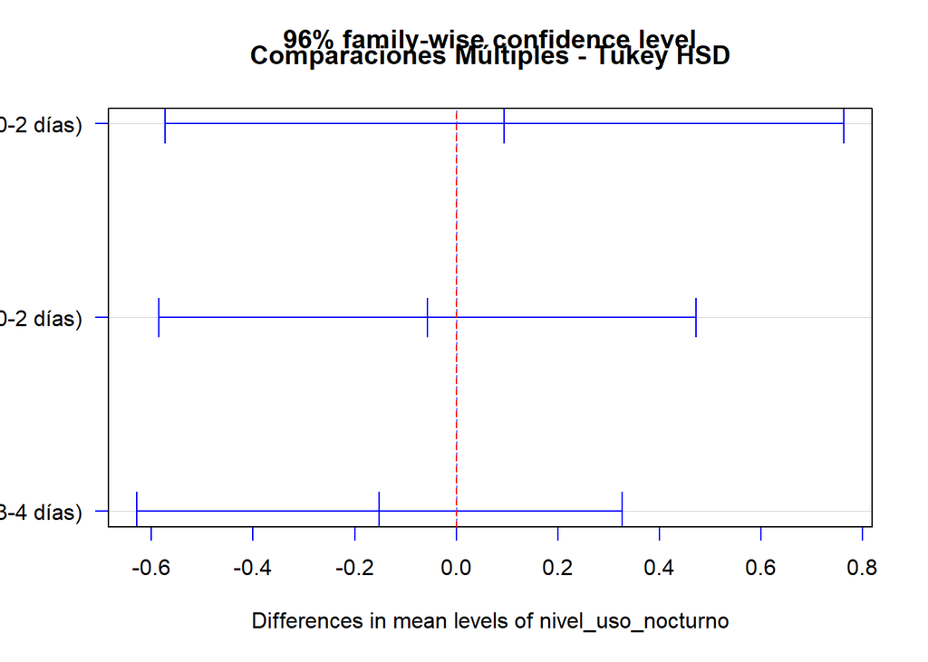

```r
# Visualización de intervalos de confianza de Tukey
plot(tukey_result, las = 1, col = "blue")
title(main = "Comparaciones Múltiples - Tukey HSD")
abline(v = 0, lty = 2, col = "red")
```

```r
# Tabla formateada de comparaciones de Tukey
tukey_df <- as.data.frame(tukey_result$nivel_uso_nocturno)
tukey_df$Comparacion <- rownames(tukey_df)
tukey_df$Significativo <- ifelse(tukey_df$`p adj` < 0.04, "Sí", "No")

tukey_tabla <- tukey_df %>%
  select(Comparacion, diff, lwr, upr, `p adj`, Significativo)

kable(tukey_tabla, digits = 4,
      caption = "Tabla 7: Comparaciones múltiples de Tukey (α = 0.04)",
      col.names = c("Comparación", "Diferencia de Medias", "Límite Inferior (96%)",
                    "Límite Superior (96%)", "p-valor ajustado", "¿Significativo?")) %>%
  kable_styling(bootstrap_options = c("striped", "hover", "condensed", "responsive"),
                full_width = TRUE, font_size = 12) %>%
  row_spec(0, bold = TRUE, color = "white", background = "#3498db")
```

Tabla 7: Comparaciones múltiples de Tukey (α = 0.04)

|  | Comparación | Diferencia de Medias | Límite Inferior (96%) | Límite Superior (96%) | p-valor ajustado | ¿Significativo? |
| --- | --- | --- | --- | --- | --- | --- |
| Moderado (3-4 días)-Bajo (0-2 días) | Moderado (3-4 días)-Bajo (0-2 días) | 0.0948 | -0.5740 | 0.7636 | 0.9361 | No |
| Alto (5-7 días)-Bajo (0-2 días) | Alto (5-7 días)-Bajo (0-2 días) | -0.0564 | -0.5851 | 0.4722 | 0.9632 | No |
| Alto (5-7 días)-Moderado (3-4 días) | Alto (5-7 días)-Moderado (3-4 días) | -0.1513 | -0.6293 | 0.3268 | 0.7202 | No |

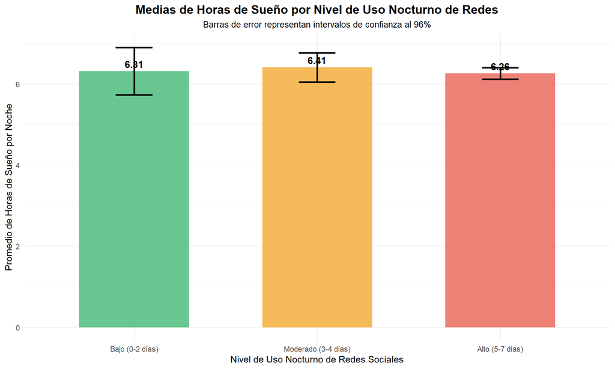

```r
# Gráfico de medias con intervalos de confianza
medias_ic <- datos_anova %>%
  group_by(nivel_uso_nocturno) %>%
  summarise(
    media = mean(horas_sueño_xnoche),
    n = n(),
    sd = sd(horas_sueño_xnoche),
    se = sd / sqrt(n),
    # IC al 96% = media ± t(0.98, n-1) * se
    ic_inferior = media - qt(0.98, n-1) * se,
    ic_superior = media + qt(0.98, n-1) * se
  )

ggplot(medias_ic, aes(x = nivel_uso_nocturno, y = media, fill = nivel_uso_nocturno)) +
  geom_bar(stat = "identity", alpha = 0.7, width = 0.6) +
  geom_errorbar(aes(ymin = ic_inferior, ymax = ic_superior),
                width = 0.2, size = 1, color = "black") +
  geom_text(aes(label = sprintf("%.2f", media)),
            vjust = -0.5, size = 4, fontface = "bold") +
  labs(title = "Medias de Horas de Sueño por Nivel de Uso Nocturno de Redes",
       subtitle = "Barras de error representan intervalos de confianza al 96%",
       x = "Nivel de Uso Nocturno de Redes Sociales",
       y = "Promedio de Horas de Sueño por Noche") +
  scale_fill_manual(values = c("#27ae60", "#f39c12", "#e74c3c")) +
  theme_minimal() +
  theme(legend.position = "none",
        plot.title = element_text(hjust = 0.5, face = "bold", size = 14),
        plot.subtitle = element_text(hjust = 0.5, size = 10))
```

## Análisis de Residuos del ANOVA

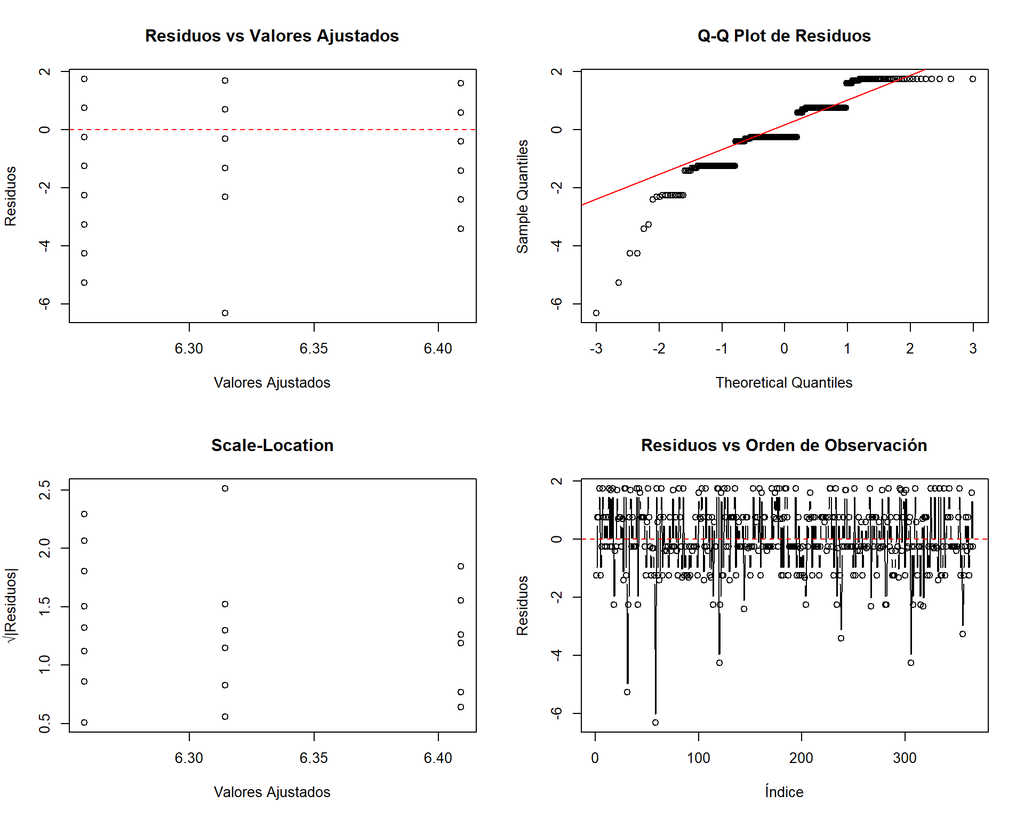

```r
# Extraer residuos y valores ajustados
residuos <- residuals(modelo_anova)
valores_ajustados <- fitted(modelo_anova)

# Gráficos de diagnóstico
par(mfrow = c(2, 2))

# 1. Residuos vs Valores Ajustados
plot(valores_ajustados, residuos,
     xlab = "Valores Ajustados", ylab = "Residuos",
     main = "Residuos vs Valores Ajustados")
abline(h = 0, col = "red", lty = 2)

# 2. Q-Q Plot de residuos
qqnorm(residuos, main = "Q-Q Plot de Residuos")
qqline(residuos, col = "red")

# 3. Scale-Location
plot(valores_ajustados, sqrt(abs(residuos)),
     xlab = "Valores Ajustados", ylab = "√|Residuos|",
     main = "Scale-Location")

# 4. Residuos vs Orden
plot(residuos, type = "b",
     xlab = "Índice", ylab = "Residuos",
     main = "Residuos vs Orden de Observación")
abline(h = 0, col = "red", lty = 2)
```

```r
# Prueba de normalidad de residuos del modelo completo
shapiro_residuos <- shapiro.test(residuos)

cat("Prueba de Shapiro-Wilk para residuos del modelo ANOVA:\n")
```

```
Prueba de Shapiro-Wilk para residuos del modelo ANOVA:
```

```r
cat(sprintf("Estadístico W = %.4f, p-valor = %.4f\n",
            shapiro_residuos$statistic, shapiro_residuos$p.value))
```

```
Estadístico W = 0.9005, p-valor = 0.0000
```

```r
if (shapiro_residuos$p.value > 0.04) {
  cat("Conclusión: Los residuos siguen una distribución normal (α = 0.04)\n")
} else {
  cat("Conclusión: Los residuos NO siguen una distribución normal (α = 0.04)\n")
}
```

```
Conclusión: Los residuos NO siguen una distribución normal (α = 0.04)
```

## Interpretación y Conclusiones del ANOVA

```r
cat("=== RESULTADOS DEL ANOVA ===\n\n")
```

```
=== RESULTADOS DEL ANOVA ===
```

```r
cat(sprintf("F-estadístico = %.4f\n", F_stat))
```

```
F-estadístico = 0.3126
```

```r
cat(sprintf("p-valor = %.6f\n", p_valor))
```

```
p-valor = 0.731774
```

```r
cat(sprintf("Nivel de significancia: α = 0.04\n\n"))
```

```
Nivel de significancia: α = 0.04
```

```r
if (p_valor < 0.04) {
  cat("DECISIÓN: Rechazamos la hipótesis nula (H₀)\n\n")
  cat("CONCLUSIÓN: Existen diferencias estadísticamente significativas en las horas de sueño\n")
  cat("promedio entre al menos dos de los grupos de uso nocturno de redes sociales.\n\n")
  cat("Esto significa que el nivel de uso nocturno de redes sociales SÍ tiene un efecto\n")
  cat("significativo sobre la cantidad de horas de sueño de los estudiantes universitarios.\n")
} else {
  cat("DECISIÓN: No rechazamos la hipótesis nula (H₀)\n\n")
  cat("CONCLUSIÓN: No existe evidencia estadística suficiente para afirmar que hay diferencias\n")
  cat("significativas en las horas de sueño promedio entre los grupos de uso nocturno de redes.\n")
}
```

```
DECISIÓN: No rechazamos la hipótesis nula (H₀)

CONCLUSIÓN: No existe evidencia estadística suficiente para afirmar que hay diferencias
significativas en las horas de sueño promedio entre los grupos de uso nocturno de redes.
```

### Interpretación de Comparaciones Post-hoc

Según las comparaciones múltiples de Tukey:

```r
for (i in 1:nrow(tukey_tabla)) {
  cat(sprintf("\n• %s:\n", tukey_tabla$Comparacion[i]))
  cat(sprintf("  Diferencia de medias: %.3f horas\n", tukey_tabla$`Diferencia de Medias`[i]))
  cat(sprintf("  IC 96%%: [%.3f, %.3f]\n",
              tukey_tabla$`Límite Inferior (96%)`[i],
              tukey_tabla$`Límite Superior (96%)`[i]))
  cat(sprintf("  p-valor ajustado: %.4f\n", tukey_tabla$`p-valor ajustado`[i]))

  if (tukey_tabla$Significativo[i] == "Sí") {
    if (tukey_tabla$`Diferencia de Medias`[i] > 0) {
      grupos <- strsplit(as.character(tukey_tabla$Comparacion[i]), "-")[[1]]
      cat(sprintf("  → El grupo '%s' duerme significativamente MÁS que '%s'\n",
                  trimws(grupos[1]), trimws(grupos[2])))
    } else {
      grupos <- strsplit(as.character(tukey_tabla$Comparacion[i]), "-")[[1]]
      cat(sprintf("  → El grupo '%s' duerme significativamente MENOS que '%s'\n",
                  trimws(grupos[1]), trimws(grupos[2])))
    }
  } else {
    cat("  → No hay diferencia significativa entre estos grupos\n")
  }
}
```

```
• Moderado (3-4 días)-Bajo (0-2 días):
  → No hay diferencia significativa entre estos grupos

• Alto (5-7 días)-Bajo (0-2 días):
  → No hay diferencia significativa entre estos grupos

• Alto (5-7 días)-Moderado (3-4 días):
  → No hay diferencia significativa entre estos grupos
```

# Conclusiones Generales

El presente estudio tuvo como propósito analizar la relación entre el uso de redes sociales, los hábitos de vida y la salud mental digital de estudiantes universitarios de 16 a 29 años matriculados en instituciones públicas y privadas durante el semestre 2025-1. Este análisis permitió comprender de manera integral cómo las prácticas digitales actuales se relacionan con el bienestar académico, emocional y físico de los estudiantes, en coherencia con los cinco objetivos planteados.

En primer lugar, los resultados descriptivos e inferenciales permitieron identificar patrones claros de uso de redes sociales, cumpliendo con el Objetivo 1. Se observó que los estudiantes presentan un uso intensivo de estas plataformas, especialmente durante las horas de la noche, lo cual coincide con estudios previos que asocian el uso nocturno con alteraciones del sueño y disminución del bienestar emocional (Younes et al., 2016; Twenge, 2019). Asimismo, los análisis evidenciaron diferencias relevantes en las rutinas diarias, la calidad del descanso y la autopercepción del impacto emocional del uso digital, indicando que estos hábitos influyen de manera directa en la vida cotidiana de los estudiantes.

En relación con el Objetivo 2, orientado a comparar el impacto del uso de redes y del contexto universitario en el rendimiento académico y la salud mental, se identificaron diferencias significativas entre estudiantes de universidades públicas y privadas en cuanto al rendimiento académico, a favor de las instituciones privadas. Este hallazgo sugiere que los factores contextuales e institucionales, junto con los hábitos digitales, influyen en el desempeño. Sin embargo, no se encontraron diferencias significativas entre ambos grupos respecto al impacto percibido de las redes sociales en la salud mental, lo cual indica que esta afectación es un fenómeno transversal en estudiantes universitarios peruanos, independientemente del tipo de institución.

Respecto al Objetivo 3, referido a evaluar la relación entre el uso de redes sociales y variables de bienestar, las pruebas de hipótesis evidenciaron que los estudiantes duermen en promedio menos de las 7 horas recomendadas, lo que representa un riesgo para su bienestar físico y cognitivo. Igualmente, los análisis demostraron que, aunque el uso nocturno no mostró una diferencia estadísticamente significativa en el impacto emocional, sí se observó una tendencia preocupante hacia una mayor afectación en quienes utilizan redes cinco o más noches por semana. En relación con la actividad física, la prueba de signos mostró que la mediana alcanza las recomendaciones mínimas de la OMS, lo que indica un nivel aceptable de ejercicio dentro de la población estudiada.

El uso de intervalos de confianza permitió, además, estimar con mayor precisión parámetros clave, como la proporción de estudiantes que emplean redes sociales con fines académicos (entre 84.75% y 91.68%). Este hallazgo resulta fundamental, pues demuestra que estas plataformas no cumplen únicamente una función recreativa, sino que también se han integrado como herramientas constantes de apoyo académico, fortaleciendo la conexión con el Objetivo 4, centrado en sensibilizar sobre el impacto del uso digital.

Por otro lado, los análisis mediante pruebas no paramétricas ofrecieron resultados valiosos para comprender las dinámicas digitales de los estudiantes. La independencia entre la plataforma más utilizada y la afectación percibida en el rendimiento académico sugiere que el problema no radica en la red social en sí, sino en el patrón y la intensidad del uso. Asimismo, la distribución no uniforme del uso a lo largo del día, altamente concentrada en la noche, refuerza las preocupaciones sobre el vínculo entre conectividad nocturna, estrés académico y deterioro de la calidad de sueño.

En conjunto, todos estos hallazgos ofrecen una visión multidimensional de la relación entre comportamiento digital y bienestar estudiantil, cumpliendo plenamente con el Objetivo 5 del curso al demostrar la aplicación rigurosa de técnicas estadísticas para comprender una problemática contemporánea de alta relevancia social. Este estudio no solo aporta evidencia empírica al contexto peruano —donde existe un vacío importante en la literatura— sino que también proporciona bases para futuras investigaciones y para el diseño de estrategias institucionales que promuevan un uso más equilibrado y saludable de las redes sociales en la comunidad universitaria.

# Recomendaciones

## Recomendaciones metodológicas para futuras investigaciones

1. Ampliar el tamaño y la diversidad de la muestra, incorporando estudiantes de más regiones del país, diferentes carreras y modalidades (presencial, semipresencial y virtual). Esto permitiría aumentar la representatividad y mejorar la capacidad de generalización de los resultados.
2. Incluir variables adicionales y más específicas, como tipo de actividad realizada en redes (consumo pasivo vs. participación activa), emociones asociadas al uso, patrones de multitarea, o mecanismos de afrontamiento digital. Esto ayudaría a profundizar en los factores que explican la afectación emocional.
3. Utilizar escalas validadas de salud mental digital, como el DASS-21, el Social Media Disorder Scale o el Fear of Missing Out Scale, para obtener mediciones más precisas y comparables a nivel internacional.
4. Aplicar diseños longitudinales, que permitan evaluar cambios en el impacto del uso digital a lo largo del semestre académico. Con ello, se podrían identificar patrones de aumento o disminución del malestar e inferir relaciones temporales con mayor claridad.
5. Complementar el enfoque cuantitativo con métodos cualitativos, como entrevistas o grupos focales, para comprender con mayor profundidad los factores subjetivos que influyen en la relación entre redes sociales, hábitos y bienestar emocional.
6. Controlar variables de confusión, como carga académica, empleo, responsabilidades familiares o presencia de trastornos previos. Esto permitiría aislar mejor el efecto del uso de redes sociales.
7. Incorporar herramientas digitales de medición objetiva, como registros de tiempo de pantalla o datos de actividad nocturna, para complementar la autopercepción de los estudiantes y reducir el sesgo de respuesta.

## Recomendaciones derivadas de los resultados del estudio

1. Promover hábitos de uso consciente de redes sociales, especialmente durante la noche. Dado que el horario nocturno concentra la mayor actividad digital y se asocia con menor calidad de sueño, se recomienda establecer rutinas tecnológicas responsables antes de dormir.
2. Fomentar el diseño de programas de educación digital universitaria, que orienten a los estudiantes sobre cómo equilibrar el uso recreativo y académico de las redes sociales, considerando que un porcentaje muy alto las utiliza con fines académicos.
3. Implementar talleres de higiene del sueño, pues se comprobó que la mayoría de estudiantes duerme menos de las 7 horas recomendadas. Esto podría incluir técnicas de desconexión digital y manejo de horarios.
4. Promover estrategias de bienestar emocional, como pausas activas, ejercicio regular y actividades fuera de entornos digitales, dado que estas influyen positivamente en el manejo del estrés académico.
5. Desarrollar campañas institucionales centradas en el uso saludable de redes, considerando que la afectación emocional no depende únicamente del número de horas, sino de los patrones de uso y los hábitos de exposición nocturna.
6. Monitorear el rendimiento académico, especialmente en estudiantes con altos niveles de uso nocturno de redes, ya que estos comportamientos pueden afectar la concentración, la motivación y el descanso.
7. Incorporar apoyo psicológico preventivo, ofreciendo recursos de orientación sobre autocontrol digital, manejo del tiempo y regulación emocional, en línea con las necesidades detectadas en la población estudiada.
8. Impulsar una cultura digital equilibrada, en la que se reconozca tanto el valor académico de las redes sociales como los riesgos asociados a su uso excesivo o desordenado.

# Bibliografía

1. Valerio Ureña, Gabriel, & Serna Valdivi, River. (2018). *Redes sociales y bienestar psicológico del estudiante universitario.* Revista electrónica de investigación educativa, 20(3), 19-28. https://doi.org/10.24320/redie.2018.20.3.1796
2. Younes, F., Halawi, G., Jabbour, H., El Osta, N., Karam, L., Hajj, A., & Rabbaa Khabbaz, L. (2016). *Internet Addiction and Relationships with Insomnia, Anxiety, Depression, Stress and Self-Esteem in University Students: A Cross-Sectional Designed Study.* PloS one, 11(9), e0161126. https://doi.org/10.1371/journal.pone.0161126
3. Twenge, J. M. (2019). *iGen: Why Today’s Super-Connected Kids Are Growing Up Less Rebellious, More Tolerant, Less Happy—and Completely Unprepared for Adulthood.* Atria Books.
4. Orben, A., & Przybylski, A. K. (2019). The association between adolescent well-being and digital technology use. *Nature Human Behaviour*, 3(2), 173-182. https://doi.org/10.1038/s41562-018-0506-1
5. James, G., Witten, D., Hastie, T., & Tibshirani, R. (2013). *An Introduction to Statistical Learning with Applications in R.* Springer.
6. Montgomery, D. C. (2017). *Design and Analysis of Experiments* (9th ed.). Wiley.
7. Field, A., Miles, J., & Field, Z. (2012). *Discovering Statistics Using R.* SAGE Publications.